# linear regression exercise

```r
##   Use the /states.rds/ data set. Fit a model predicting energy consumed per capita (energy) from the percentage of residents living in metropolitan areas (metro).
# set the working directory
setwd("F:/_data science references/_assignments/linear_regression")
# list files in directory
list.files("dataSets") # files in the dataSets folder
```

```
[1] "Exam.rds"   "states.dta" "states.rds"
```

```r
# read the states data
states.data <- readRDS("dataSets/states.rds")
# store labels
states.info <- data.frame(attributes(states.data)[c("names", "var.labels")])
##   1. Examine/ plot the data before fitting the model
# return a summary of the subset of all records based on the energy and metro columns
metEnergy <- subset(states.data, select = c("metro", "energy"))
summary(metEnergy) # returns min, max, median values for each column and a count of NA values
```

```
     metro            energy
 Min.   : 20.40   Min.   :200.0
 1st Qu.: 46.98   1st Qu.:285.0
 Median : 67.55   Median :320.0
 Mean   : 64.07   Mean   :354.5
 3rd Qu.: 81.58   3rd Qu.:371.5
 Max.   :100.00   Max.   :991.0
 NA's   :1        NA's   :1
```

```r
cor(metEnergy) # correlation between energy and metro
```

```
       metro energy
metro      1     NA
energy    NA      1
```

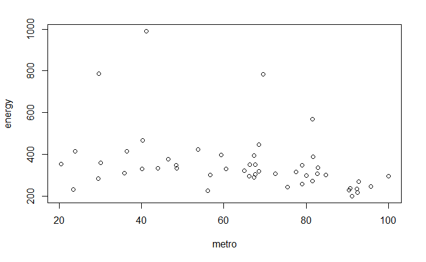

```r
# scatterplot of data before fitting model
plot(metEnergy)
```

```r
##   2. Print and interpret the model `summary'
# fit a linear regression model
en.mod <- lm(energy ~ metro, data = states.data)
# Summarize and print the results
summary(en.mod) # show regression coefficients table
```

```
Call:
lm(formula = energy ~ metro, data = states.data)

Residuals:
    Min      1Q  Median      3Q     Max
-215.51  -64.54  -30.87   18.71  583.97

Coefficients:
            Estimate Std. Error t value Pr(>|t|)
(Intercept) 501.0292    61.8136   8.105 1.53e-10 ***
metro        -2.2871     0.9139  -2.503   0.0158 *
---
Signif. codes:  0 *** 0.001 ** 0.01 * 0.05 . 0.1   1

Residual standard error: 140.2 on 48 degrees of freedom
  (1 observation deleted due to missingness)
Multiple R-squared:  0.1154,    Adjusted R-squared:  0.097
F-statistic: 6.263 on 1 and 48 DF,  p-value: 0.01578
```

```r
# Multiple R-squared:  0.1154
```

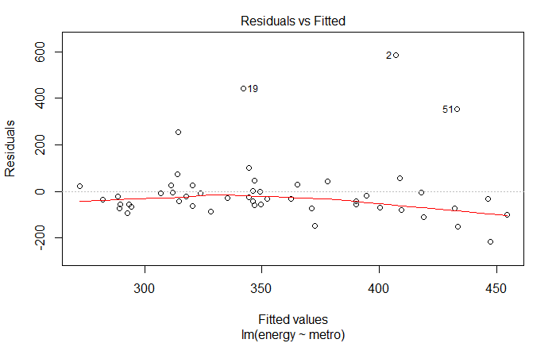

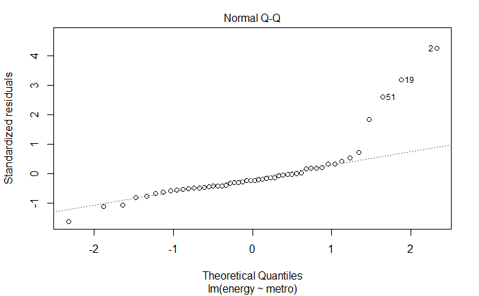

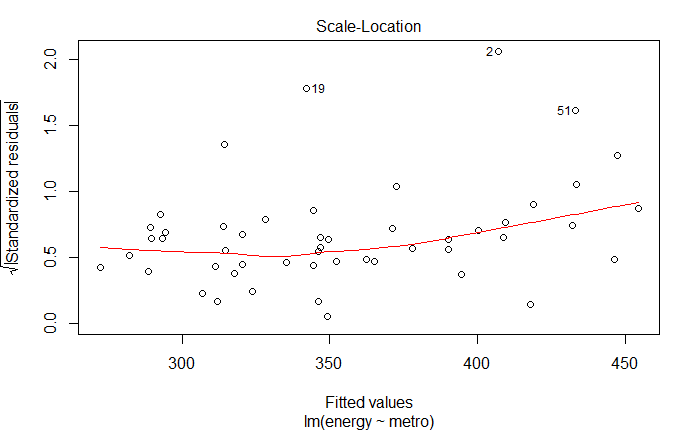

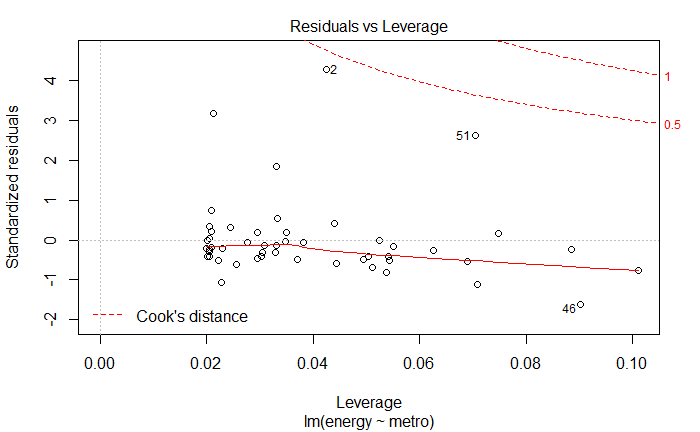

The residuals vs. fitted plot indicate whether the residuals have non-linear patterns. This resultant plot is not evenly distributed vertically with several identified outliers. Inclusion of another predictor may explain the larger x-axis datapoints.

The Q-Q plot returns a straight line distribution of points if the errors are normally distributed. In this case, the points deviate in one extremity. This indicates that the data base more extreme values than would be expected if the points would otherwise be normally distributed.

The scale-location plot result challenges the assumption of homosecedasiticty or equal variance, since the resulting red line us displayed at an angle. Ideally, the line would be horizontal if the residuals are spread equally along the range of predictors.

The residuals vs. leverage plot helps to identify points that may influence the model more than others (if any exist); while data may contain extreme values, these are not considered to be influential to the determination of the regression line (i.e. results will not change notably with the inclusion or exclusion of the points from the overall analysis). Cook’s distance indicated by dashed, red lines; influential points are identified with high Cook’s distance scores. In this case, no particular points are considered to be highly influential.

```r
metEnergy2 <- subset(states.data, select = c("metro", "waste", "energy"))
summary(metEnergy2) # returns min, max, median values for each column and a count of NA values
```

```
     metro            waste            energy
 Min.   : 20.40   Min.   :0.5400   Min.   :200.0
 1st Qu.: 46.98   1st Qu.:0.8225   1st Qu.:285.0
 Median : 67.55   Median :0.9600   Median :320.0
 Mean   : 64.07   Mean   :0.9888   Mean   :354.5
 3rd Qu.: 81.58   3rd Qu.:1.1450   3rd Qu.:371.5
 Max.   :100.00   Max.   :1.5100   Max.   :991.0
 NA's   :1        NA's   :1        NA's   :1
```

```r
cor(metEnergy2)
```

```
       metro waste energy
metro      1    NA     NA
waste     NA     1     NA
energy    NA    NA      1
```

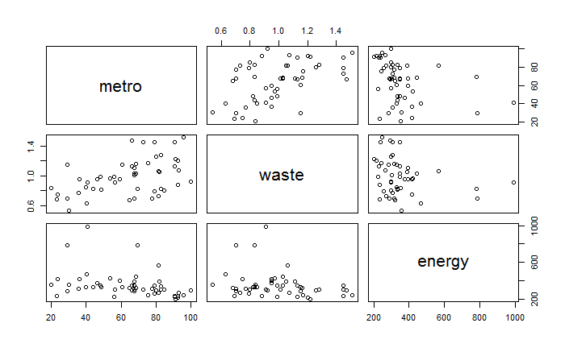

```r
# scatterplot of data before fitting model
plot(metEnergy2)
```

```r
##   2. Print and interpret the model `summary'
# fit a linear regression model
en.mod2 <- lm(energy ~ metro + waste, data = states.data)
# Summarize and print the results
summary(en.mod2) # show regression coefficients table
```

```
Call:
lm(formula = energy ~ metro + waste, data = states.data)

Residuals:
    Min      1Q  Median      3Q     Max
-221.40  -73.28  -27.00    8.38  587.00

Coefficients:
            Estimate Std. Error t value Pr(>|t|)
(Intercept)  546.917     88.377   6.188 1.39e-07 ***
metro         -1.913      1.052  -1.818   0.0754 .
waste        -70.677     96.825  -0.730   0.4690
---
Signif. codes:  0 *** 0.001 ** 0.01 * 0.05 . 0.1   1

Residual standard error: 140.9 on 47 degrees of freedom
  (1 observation deleted due to missingness)
Multiple R-squared:  0.1253,    Adjusted R-squared:  0.08812
F-statistic: 3.368 on 2 and 47 DF,  p-value: 0.04297
```

```r
# Multiple R-squared:  0.1253 compared with 0.1154 indicates a slight improvement
```

```r
metEnergy3 <- subset(states.data, select = c("metro", "waste", "density", "energy"))
summary(metEnergy3) # returns min, max, median values for each column and a count of NA values
```

```
     metro            waste           density            energy
 Min.   : 20.40   Min.   :0.5400   Min.   :   0.96   Min.   :200.0
 1st Qu.: 46.98   1st Qu.:0.8225   1st Qu.:  31.88   1st Qu.:285.0
 Median : 67.55   Median :0.9600   Median :  75.76   Median :320.0
 Mean   : 64.07   Mean   :0.9888   Mean   : 166.04   Mean   :354.5
 3rd Qu.: 81.58   3rd Qu.:1.1450   3rd Qu.: 170.29   3rd Qu.:371.5
 Max.   :100.00   Max.   :1.5100   Max.   :1041.92   Max.   :991.0
 NA's   :1        NA's   :1        NA's   :1         NA's   :1
```

```r
cor(metEnergy3)
```

```
        metro waste density energy
metro       1    NA      NA     NA
waste      NA     1      NA     NA
density    NA    NA       1     NA
energy     NA    NA      NA      1
```

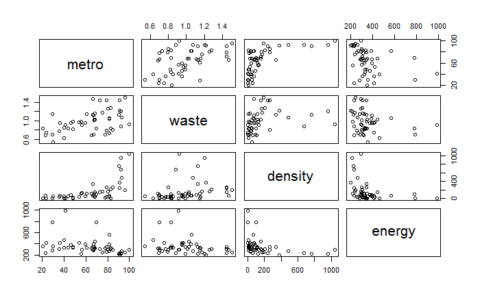

```r
# scatterplot of data before fitting model
plot(metEnergy3)
```

```r
##   2. Print and interpret the model `summary'
# fit a linear regression model
en.mod3 <- lm(energy ~ metro + waste + density, data = states.data)
# Summarize and print the results
summary(en.mod3) # show regression coefficients table
```

```
Call:
lm(formula = energy ~ metro + waste + density, data = states.data)

Residuals:
    Min      1Q  Median      3Q     Max
-202.12  -71.54  -30.26   17.89  585.04

Coefficients:
            Estimate Std. Error t value Pr(>|t|)
(Intercept) 518.8913    91.1934   5.690 8.42e-07 ***
metro        -1.0819     1.2638  -0.856    0.396
waste       -75.1090    96.5087  -0.778    0.440
density      -0.1253     0.1066  -1.175    0.246
---
Signif. codes:  0 *** 0.001 ** 0.01 * 0.05 . 0.1   1

Residual standard error: 140.3 on 46 degrees of freedom
  (1 observation deleted due to missingness)
Multiple R-squared:  0.1508,    Adjusted R-squared:  0.09546
F-statistic: 2.724 on 3 and 46 DF,  p-value: 0.05501
```

```r
en.modInt <- lm(energy ~ metro*density, data = states.data)
# return results of adding the interaction term
coef(summary(en.modInt))
```

```
                  Estimate   Std. Error   t value     Pr(>|t|)
(Intercept)   514.10424265 72.513405133  7.089782 6.683817e-09
metro          -1.72111951  1.135554671 -1.515664 1.364465e-01
density        -1.43817898  0.911292059 -1.578176 1.213782e-01
metro:density   0.01386147  0.009534258  1.453859 1.527747e-01
```

```r
str(states.data$region)
```

```
 Factor w/ 4 levels "West","N. East",..: 3 1 1 3 1 1 2 3 NA 3 ...
```

```r
states.data$region <- factor(states.data$region)
# add region to the model
en.modReg <- lm(energy ~ region, data = states.data)
# show the results: regression coefficients and ANOVA tables
coef(summary(en.modReg))
```

```
                Estimate Std. Error    t value     Pr(>|t|)
(Intercept)    405.61538   39.23196 10.3389019 1.395176e-13
regionN. East -156.50427   61.33807 -2.5515032 1.411486e-02
regionSouth    -25.49038   52.81764 -0.4826112 6.316606e-01
regionMidwest  -61.61538   56.62646 -1.0881024 2.822182e-01
```

```r
anova(en.modReg)
```

```
Analysis of Variance Table

Response: energy
          Df Sum Sq Mean Sq F value  Pr(>F)
region     3 145757   48586  2.4282 0.07737 .
Residuals 46 920410   20009
---
Signif. codes:  0 *** 0.001 ** 0.01 * 0.05 . 0.1   1
```

A larger, insignificant p-value suggests that the predictor are not associated to changes in the response; south and midwest p-values > 0.05, indicate that these regions are not statistically significant, whereas northeast region with a p-value of 0.01 is likely to be a meaningful addition to the model.